# Feature Engineering

### Introduction

**GOAL**: Build a dataset that can either be used for (a) customer segmentation, or (b) predicting “good” customers, where “good” customers are defined as those who are in the upper half of the population for yearly spending.

```r
library(tidyverse)
library(lubridate)

setwd("D:/My Documents/FTW/2023 Batch 7/Day 9")
df_flights <- fread("customer_flights.csv")
df_customer <- fread("customer_table.csv")
```

```r
head(df_customer, 20)
```

| customer_id | age | sex | region | major_region | married | no_of_children |
| --- | --- | --- | --- | --- | --- | --- |
| 1 | 36 | F | Region 3 - Central Luzon | Luzon | TRUE | 2 |
| 2 | 37 | M | Region 9 - Zamboanga | Mindanao | FALSE | 0 |
| 3 | 29 | M | Region 6 - W. Visayas | Visayas | FALSE | 2 |
| 4 | 25 | F | Region 3 - Central Luzon | Luzon | TRUE | 1 |
| 5 | 36 | F | Region 4 - CALABARZON | Luzon | FALSE | 0 |
| 6 | 15 | M | Region 7 - C. Visayas | Visayas | FALSE | 0 |
| 7 | 36 | M | Region 4 - CALABARZON | Luzon | FALSE | 0 |
| 8 | 27 | M | Region 4 - CALABARZON | Luzon | TRUE | 0 |
| 9 | 27 | F | Region 11 - Davao | Mindanao | TRUE | 0 |
| 10 | 21 | M | Region 12 - SOCCKSARGEN | Mindanao | TRUE | 0 |

[output cut: 10 more lines]

```r
head(df_flights, 20)
```

| transaction_id | customer_id | flight_destination | flight_date | n_guests | booking_date | total_spend | flight_type |
| --- | --- | --- | --- | --- | --- | --- | --- |
| 1 | 1 | Domestic | 2022-05-25 | 6 | 2022-05-16 | 4927.603 | Round-Trip |
| 2 | 1 | Domestic | 2022-12-04 | 4 | 2022-11-23 | 12057.894 | Round-Trip |
| 3 | 2 | Domestic | 2022-11-10 | 1 | 2022-10-22 | 5278.180 | Round-Trip |
| 4 | 2 | Long Haul | 2022-12-03 | 1 | 2022-10-01 | 11990.266 | One-way |
| 5 | 2 | Domestic | 2022-12-08 | 1 | 2022-11-29 | 4199.343 | Round-Trip |
| 6 | 2 | Domestic | 2022-11-06 | 3 | 2022-10-22 | 2693.797 | One-way |
| 7 | 2 | Short Haul | 2022-11-22 | 1 | 2022-09-26 | 4108.764 | One-way |
| 8 | 2 | Domestic | 2022-12-06 | 1 | 2022-11-22 | 3657.961 | One-way |
| 9 | 3 | Short Haul | 2022-10-26 | 3 | 2022-08-28 | 25777.755 | Round-Trip |
| 10 | 3 | Domestic | 2022-12-27 | 1 | 2022-12-14 | 2503.457 | One-way |

[output cut: 10 more lines]

**Given the use case, what does your “final” dataset look like?**

- What’s the *granularity* of the dataset?
- What information makes sense to have in the dataset?
- Given all the raw data available, what *concepts* or *behaviors* do you want to represent?
- What’s the most efficient way to represent all our data numerically?

Our transaction data set has information on each flight that each customer flew in 2022:

- Destination Type
- Flight Departure Date
- Booking Size
- Date of Booking
- Total Spend (in the booking)
- Trip Type

What are some **customer-level** behaviors that we’d want to model/represent using this dataset?

- Average spend per flight
- Usual # of companions/do they usually travel alone?
- Do they usually fly one-way?
- How many flights did they book?
- What’s their usual lead time when between booking and departure?

### Deriving Features from Flights Dataset

#### Encoding Categoricals

```r
df_flights$flight_destination %>%
  table
```

```
.
  Domestic  Long Haul Short Haul
     11192       3752       5063
```

We have a few options: 1. Create 2 (or 3) dummy variables, one each for Dom, LH, SH 2. Group LH and SH together as INTL, and have just a binary variable to take care of destination type

```r
df_flights$flight_type %>%
  table
```

```
.
   One-way   Open Jaw Round-Trip
     12614       1327       6066
```

Similar case to above - with 3 options, but this time the imbalance in Open Jaw prevalence is even stronger.

```r
df_flights_1 <- df_flights %>%
  mutate(is_flight_domestic  = 1 * (flight_destination == "Domestic"),
         is_flight_one_way = 1 * (flight_type == "One-way"))

df_flights_1 %>%
  head(100)
```

| transaction_id | customer_id | flight_destination | flight_date | n_guests | booking_date | total_spend | flight_type | is_flight_domestic | is_flight_one_way |
| --- | --- | --- | --- | --- | --- | --- | --- | --- | --- |
| 1 | 1 | Domestic | 2022-05-25 | 6 | 2022-05-16 | 4927.603 | Round-Trip | 1 | 0 |
| 2 | 1 | Domestic | 2022-12-04 | 4 | 2022-11-23 | 12057.894 | Round-Trip | 1 | 0 |
| 3 | 2 | Domestic | 2022-11-10 | 1 | 2022-10-22 | 5278.180 | Round-Trip | 1 | 0 |
| 4 | 2 | Long Haul | 2022-12-03 | 1 | 2022-10-01 | 11990.266 | One-way | 0 | 1 |
| 5 | 2 | Domestic | 2022-12-08 | 1 | 2022-11-29 | 4199.343 | Round-Trip | 1 | 0 |
| 6 | 2 | Domestic | 2022-11-06 | 3 | 2022-10-22 | 2693.797 | One-way | 1 | 1 |
| 7 | 2 | Short Haul | 2022-11-22 | 1 | 2022-09-26 | 4108.764 | One-way | 0 | 1 |
| 8 | 2 | Domestic | 2022-12-06 | 1 | 2022-11-22 | 3657.961 | One-way | 1 | 1 |
| 9 | 3 | Short Haul | 2022-10-26 | 3 | 2022-08-28 | 25777.755 | Round-Trip | 0 | 0 |
| 10 | 3 | Domestic | 2022-12-27 | 1 | 2022-12-14 | 2503.457 | One-way | 1 | 1 |

[output cut: 90 more lines]

#### Dealing with Dates

We have information on flight dates and booking dates. We could use this to represent things such as:

- Time between booking and departure
- Usual season flown
- Usual season departed

Are all 3 of these necessary at the same time? Are they independent?

```r
df_flights_2 <- df_flights_1 %>%
  mutate(ndo = as.numeric(difftime(flight_date, booking_date,  units  = "days")),
         quarter_flown = quarter(flight_date))

df_flights_2 %>% head(100)
```

| transaction_id | customer_id | flight_destination | flight_date | n_guests | booking_date | total_spend | flight_type | is_flight_domestic | is_flight_one_way | ndo | quarter_flown |
| --- | --- | --- | --- | --- | --- | --- | --- | --- | --- | --- | --- |
| 1 | 1 | Domestic | 2022-05-25 | 6 | 2022-05-16 | 4927.603 | Round-Trip | 1 | 0 | 9 | 2 |
| 2 | 1 | Domestic | 2022-12-04 | 4 | 2022-11-23 | 12057.894 | Round-Trip | 1 | 0 | 11 | 4 |
| 3 | 2 | Domestic | 2022-11-10 | 1 | 2022-10-22 | 5278.180 | Round-Trip | 1 | 0 | 19 | 4 |
| 4 | 2 | Long Haul | 2022-12-03 | 1 | 2022-10-01 | 11990.266 | One-way | 0 | 1 | 63 | 4 |
| 5 | 2 | Domestic | 2022-12-08 | 1 | 2022-11-29 | 4199.343 | Round-Trip | 1 | 0 | 9 | 4 |
| 6 | 2 | Domestic | 2022-11-06 | 3 | 2022-10-22 | 2693.797 | One-way | 1 | 1 | 15 | 4 |
| 7 | 2 | Short Haul | 2022-11-22 | 1 | 2022-09-26 | 4108.764 | One-way | 0 | 1 | 57 | 4 |
| 8 | 2 | Domestic | 2022-12-06 | 1 | 2022-11-22 | 3657.961 | One-way | 1 | 1 | 14 | 4 |
| 9 | 3 | Short Haul | 2022-10-26 | 3 | 2022-08-28 | 25777.755 | Round-Trip | 0 | 0 | 59 | 4 |
| 10 | 3 | Domestic | 2022-12-27 | 1 | 2022-12-14 | 2503.457 | One-way | 1 | 1 | 13 | 4 |

[output cut: 90 more lines]

Remember that we’ll be aggregating this later on to a customer level; how sensible are the representations we’ve made so far? Are they aggregable?

#### Deriving from numerics

We have total number of guests and total spend - therse generally look fine on their own, but we could get some interesting information by performing some algebra on them to get info such as:

- Average spend per head (for a given flight) - this one’s just simple algebra
- Do we need to “correct” for any skewed distributions?

Let’s check for any skewed distributions:

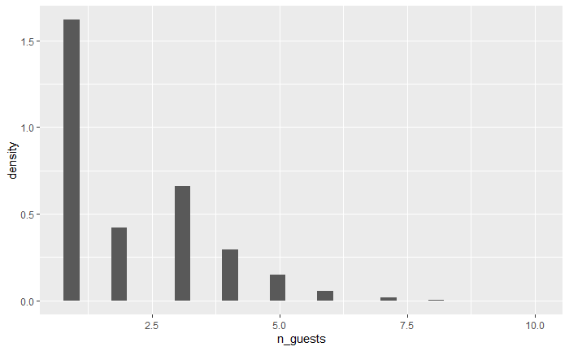

```r
df_flights_2 %>%
  ggplot(aes(x = n_guests)) +
  geom_histogram(aes(y = ..density..))
```

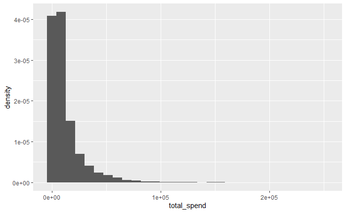

```r
df_flights_2 %>%
  ggplot(aes(x = total_spend)) +
  geom_histogram(aes(y = ..density..))
```

Unlike the number of guests, distribution of total spend is a lot more skewed. We may want to apply some variance correction here to try to normalize the variable somewhere. Consider either getting the square root (since spend is always > 0) or the log.

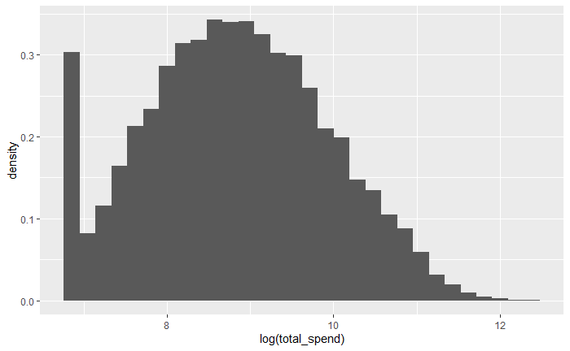

```r
df_flights_2 %>%
  ggplot(aes(x = log(total_spend))) +
  geom_histogram(aes(y =..density..))
```

Another possible way we can “control” the spend is by getting the average spend per head instead. Beware though, we’re creating multiple new variables all related to spend - before the end of this exercise, we’ll likely have to choose only some of them to keep.

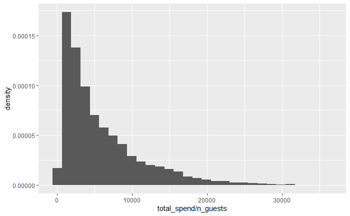

```r
df_flights_2 %>%
  ggplot(aes(x = total_spend/n_guests)) +
  geom_histogram(aes(y=..density..))
```

```r
df_flights_3 <- df_flights_2 %>%
  mutate(log_spend = log(total_spend))

df_flights_3 %>%
  head(200)
```

| transaction_id | customer_id | flight_destination | flight_date | n_guests | booking_date | total_spend | flight_type | is_flight_domestic | is_flight_one_way | ndo | quarter_flown | log_spend |
| --- | --- | --- | --- | --- | --- | --- | --- | --- | --- | --- | --- | --- |
| 1 | 1 | Domestic | 2022-05-25 | 6 | 2022-05-16 | 4927.603 | Round-Trip | 1 | 0 | 9 | 2 | 8.502608 |
| 2 | 1 | Domestic | 2022-12-04 | 4 | 2022-11-23 | 12057.894 | Round-Trip | 1 | 0 | 11 | 4 | 9.397475 |
| 3 | 2 | Domestic | 2022-11-10 | 1 | 2022-10-22 | 5278.180 | Round-Trip | 1 | 0 | 19 | 4 | 8.571337 |
| 4 | 2 | Long Haul | 2022-12-03 | 1 | 2022-10-01 | 11990.266 | One-way | 0 | 1 | 63 | 4 | 9.391850 |
| 5 | 2 | Domestic | 2022-12-08 | 1 | 2022-11-29 | 4199.343 | Round-Trip | 1 | 0 | 9 | 4 | 8.342683 |
| 6 | 2 | Domestic | 2022-11-06 | 3 | 2022-10-22 | 2693.797 | One-way | 1 | 1 | 15 | 4 | 7.898707 |
| 7 | 2 | Short Haul | 2022-11-22 | 1 | 2022-09-26 | 4108.764 | One-way | 0 | 1 | 57 | 4 | 8.320878 |
| 8 | 2 | Domestic | 2022-12-06 | 1 | 2022-11-22 | 3657.961 | One-way | 1 | 1 | 14 | 4 | 8.204661 |
| 9 | 3 | Short Haul | 2022-10-26 | 3 | 2022-08-28 | 25777.755 | Round-Trip | 0 | 0 | 59 | 4 | 10.157267 |
| 10 | 3 | Domestic | 2022-12-27 | 1 | 2022-12-14 | 2503.457 | One-way | 1 | 1 | 13 | 4 | 7.825428 |

[output cut: 190 more lines]

#### Aggregation

Given our transactional database, how do we want to move it to a customer-level? What types of aggregations make sense?

- Do we just get the average of everything?
- Are there variables where the minima or maxima matter?
- Are there variables there variables we just want the mode for?
- Are we choosing variables that are orthogonal/linearly independent (at least, conceptually)

```r
quarter_most_flown <- df_flights_3 %>%
  group_by(customer_id, quarter_flown) %>%
  summarize(n = n()) %>%
  ungroup %>%
  group_by(customer_id) %>%
  slice_max(n, with_ties = FALSE)  ## Just choose randomly if there are ties - do at your own risk
quarter_most_flown %>%
  head(100)
```

| customer_id | quarter_flown | n |
| --- | --- | --- |
| 1 | 2 | 1 |
| 2 | 4 | 6 |
| 3 | 4 | 2 |
| 4 | 4 | 4 |
| 5 | 2 | 1 |
| 6 | 4 | 2 |
| 7 | 4 | 2 |
| 8 | 2 | 1 |
| 9 | 4 | 1 |
| 10 | 4 | 2 |

[output cut: 90 more lines]

```r
df_flights_clevel <- df_flights_3 %>%
  group_by(customer_id) %>%
  summarize(n_flights = n(),
            ave_guests = mean(n_guests),
            max_guests = max(n_guests),
            min_guests = min(n_guests),
            ave_log_spend = mean(log_spend),
            max_log_spend = max(log_spend),
            total_spend = sum(total_spend),
            p_domestic = mean(is_flight_domestic),
            p_oneway = mean(is_flight_one_way),
            ave_ndo = mean(ndo),
            max_ndo = max(ndo),
            min_ndo = min(ndo)) %>%
  left_join(quarter_most_flown, by = "customer_id")

df_flights_clevel %>%
  head(200)
```

| customer_id | n_flights | ave_guests | max_guests | min_guests | ave_log_spend | max_log_spend | total_spend | p_domestic | p_oneway | ave_ndo | max_ndo | min_ndo | quarter_flown | n |
| --- | --- | --- | --- | --- | --- | --- | --- | --- | --- | --- | --- | --- | --- | --- |
| 1 | 2 | 5.000000 | 6 | 4 | 8.950041 | 9.397475 | 16985.496 | 1.0000000 | 0.0000000 | 10.00000 | 11 | 9 | 2 | 1 |
| 2 | 6 | 1.333333 | 3 | 1 | 8.455019 | 9.391850 | 31928.312 | 0.6666667 | 0.6666667 | 29.50000 | 63 | 9 | 4 | 6 |
| 3 | 2 | 2.000000 | 3 | 1 | 8.991347 | 10.157267 | 28281.212 | 0.5000000 | 0.5000000 | 36.00000 | 59 | 13 | 4 | 2 |
| 4 | 4 | 3.000000 | 6 | 2 | 9.695430 | 10.761128 | 86420.130 | 0.2500000 | 1.0000000 | 49.50000 | 67 | 12 | 4 | 4 |
| 5 | 1 | 1.000000 | 1 | 1 | 7.494683 | 7.494683 | 1798.454 | 1.0000000 | 1.0000000 | 20.00000 | 20 | 20 | 2 | 1 |
| 6 | 3 | 1.666667 | 3 | 1 | 9.142434 | 9.855820 | 38284.818 | 0.3333333 | 0.3333333 | 41.33333 | 56 | 19 | 4 | 2 |
| 7 | 3 | 1.666667 | 3 | 1 | 7.667244 | 8.644541 | 8397.953 | 1.0000000 | 0.6666667 | 15.33333 | 17 | 13 | 4 | 2 |
| 8 | 2 | 4.000000 | 4 | 4 | 8.746109 | 9.005921 | 12999.089 | 1.0000000 | 0.5000000 | 17.00000 | 20 | 14 | 2 | 1 |
| 9 | 1 | 2.000000 | 2 | 2 | 8.184366 | 8.184366 | 3584.471 | 1.0000000 | 1.0000000 | 12.00000 | 12 | 12 | 4 | 1 |
| 10 | 2 | 3.000000 | 4 | 2 | 10.641284 | 11.142909 | 94400.116 | 0.0000000 | 0.5000000 | 60.50000 | 70 | 51 | 4 | 2 |

[output cut: 190 more lines]

For now, I’ve kept more variables in than I’ll eventuall use. We can prune later on, once we see the full size of our dataset (and all possibly related features).

### Deriving Features from Customer Dataset

```r
df_customer %>% head(20)
```

| customer_id | age | sex | region | major_region | married | no_of_children |
| --- | --- | --- | --- | --- | --- | --- |
| 1 | 36 | F | Region 3 - Central Luzon | Luzon | TRUE | 2 |
| 2 | 37 | M | Region 9 - Zamboanga | Mindanao | FALSE | 0 |
| 3 | 29 | M | Region 6 - W. Visayas | Visayas | FALSE | 2 |
| 4 | 25 | F | Region 3 - Central Luzon | Luzon | TRUE | 1 |
| 5 | 36 | F | Region 4 - CALABARZON | Luzon | FALSE | 0 |
| 6 | 15 | M | Region 7 - C. Visayas | Visayas | FALSE | 0 |
| 7 | 36 | M | Region 4 - CALABARZON | Luzon | FALSE | 0 |
| 8 | 27 | M | Region 4 - CALABARZON | Luzon | TRUE | 0 |
| 9 | 27 | F | Region 11 - Davao | Mindanao | TRUE | 0 |
| 10 | 21 | M | Region 12 - SOCCKSARGEN | Mindanao | TRUE | 0 |

[output cut: 10 more lines]

#### Correcting Distributions

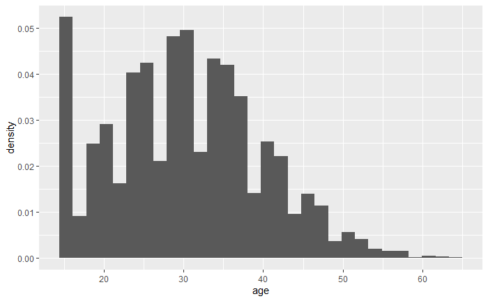

```r
df_customer %>%
  ggplot(aes(x = age)) +
  geom_histogram(aes(y=..density..))
```

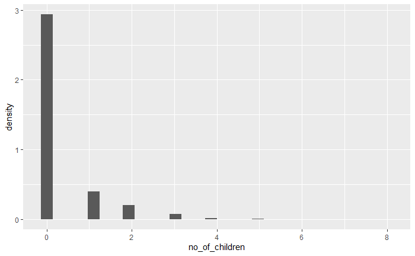

```r
df_customer %>%
  ggplot(aes(x = no_of_children)) +
  geom_histogram(aes(y=..density..))
```

Extremely skewed, with 0’s over-represented. With this type of imbalance, it might be better to encode this as a binary (has_children).

#### Encoding Regions

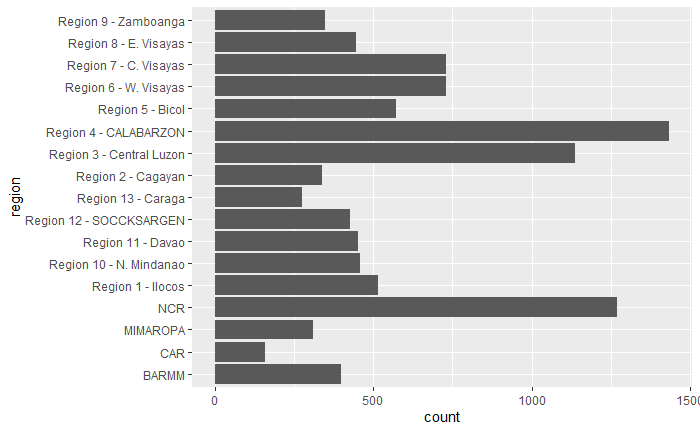

```r
df_customer %>%
  ggplot(aes(x = region)) +
  geom_bar() +
  coord_flip()
```

Some regions under-represented, but the fact is there’s just too many of them to make dummy variables for. We have a few options here:

- Group them by Luzon, Visayas, Mindanao (and check later on if the three bins end up relatively balanced)
- Represent each region using metrics describing it such as: ** Population ** Density ** Economic Activity/Urbanization ** etc.

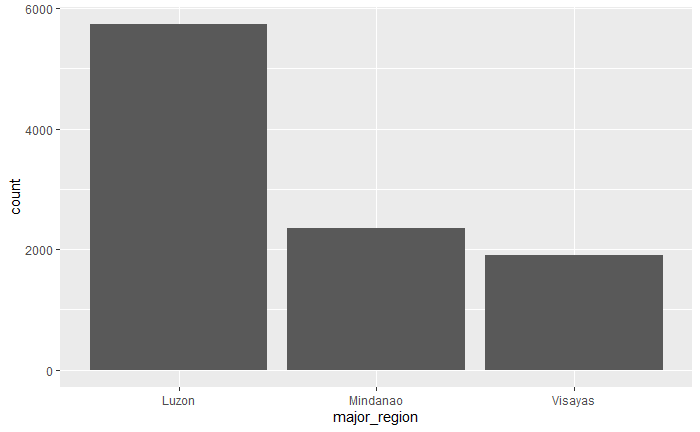

```r
df_customer %>%
  ggplot(aes(x = major_region)) +
  geom_bar()
```

Worth exploring and simplifying into a binary `is_luzon`.

```r
df_customer_prep <- df_customer %>%
  mutate(is_luzon = 1 * (major_region == "Luzon"),
         has_children = 1 * (no_of_children >= 1),
         is_married = 1 * married)

df_customer_prep %>%
  head(100)
```

| customer_id | age | sex | region | major_region | married | no_of_children | is_luzon | has_children | is_married |
| --- | --- | --- | --- | --- | --- | --- | --- | --- | --- |
| 1 | 36 | F | Region 3 - Central Luzon | Luzon | TRUE | 2 | 1 | 1 | 1 |
| 2 | 37 | M | Region 9 - Zamboanga | Mindanao | FALSE | 0 | 0 | 0 | 0 |
| 3 | 29 | M | Region 6 - W. Visayas | Visayas | FALSE | 2 | 0 | 1 | 0 |
| 4 | 25 | F | Region 3 - Central Luzon | Luzon | TRUE | 1 | 1 | 1 | 1 |
| 5 | 36 | F | Region 4 - CALABARZON | Luzon | FALSE | 0 | 1 | 0 | 0 |
| 6 | 15 | M | Region 7 - C. Visayas | Visayas | FALSE | 0 | 0 | 0 | 0 |
| 7 | 36 | M | Region 4 - CALABARZON | Luzon | FALSE | 0 | 1 | 0 | 0 |
| 8 | 27 | M | Region 4 - CALABARZON | Luzon | TRUE | 0 | 1 | 0 | 1 |
| 9 | 27 | F | Region 11 - Davao | Mindanao | TRUE | 0 | 0 | 0 | 1 |
| 10 | 21 | M | Region 12 - SOCCKSARGEN | Mindanao | TRUE | 0 | 0 | 0 | 1 |

[output cut: 90 more lines]

### Joining and Initial Selection

```r
df_big <- df_customer_prep %>%
  left_join(df_flights_clevel, by = "customer_id")

df_big
```

| customer_id | age | sex | region | major_region | married | no_of_children | is_luzon | has_children | is_married | n_flights | ave_guests | max_guests | min_guests | ave_log_spend | max_log_spend | total_spend | p_domestic | p_oneway | ave_ndo | max_ndo | min_ndo | quarter_flown | n |
| --- | --- | --- | --- | --- | --- | --- | --- | --- | --- | --- | --- | --- | --- | --- | --- | --- | --- | --- | --- | --- | --- | --- | --- |
| 1 | 36 | F | Region 3 - Central Luzon | Luzon | TRUE | 2 | 1 | 1 | 1 | 2 | 5.000000 | 6 | 4 | 8.950041 | 9.397475 | 16985.496 | 1.0000000 | 0.0000000 | 10.00000 | 11 | 9 | 2 | 1 |
| 2 | 37 | M | Region 9 - Zamboanga | Mindanao | FALSE | 0 | 0 | 0 | 0 | 6 | 1.333333 | 3 | 1 | 8.455019 | 9.391850 | 31928.312 | 0.6666667 | 0.6666667 | 29.50000 | 63 | 9 | 4 | 6 |
| 3 | 29 | M | Region 6 - W. Visayas | Visayas | FALSE | 2 | 0 | 1 | 0 | 2 | 2.000000 | 3 | 1 | 8.991347 | 10.157267 | 28281.212 | 0.5000000 | 0.5000000 | 36.00000 | 59 | 13 | 4 | 2 |
| 4 | 25 | F | Region 3 - Central Luzon | Luzon | TRUE | 1 | 1 | 1 | 1 | 4 | 3.000000 | 6 | 2 | 9.695430 | 10.761128 | 86420.130 | 0.2500000 | 1.0000000 | 49.50000 | 67 | 12 | 4 | 4 |
| 5 | 36 | F | Region 4 - CALABARZON | Luzon | FALSE | 0 | 1 | 0 | 0 | 1 | 1.000000 | 1 | 1 | 7.494683 | 7.494683 | 1798.454 | 1.0000000 | 1.0000000 | 20.00000 | 20 | 20 | 2 | 1 |
| 6 | 15 | M | Region 7 - C. Visayas | Visayas | FALSE | 0 | 0 | 0 | 0 | 3 | 1.666667 | 3 | 1 | 9.142434 | 9.855820 | 38284.818 | 0.3333333 | 0.3333333 | 41.33333 | 56 | 19 | 4 | 2 |
| 7 | 36 | M | Region 4 - CALABARZON | Luzon | FALSE | 0 | 1 | 0 | 0 | 3 | 1.666667 | 3 | 1 | 7.667244 | 8.644541 | 8397.953 | 1.0000000 | 0.6666667 | 15.33333 | 17 | 13 | 4 | 2 |
| 8 | 27 | M | Region 4 - CALABARZON | Luzon | TRUE | 0 | 1 | 0 | 1 | 2 | 4.000000 | 4 | 4 | 8.746109 | 9.005921 | 12999.089 | 1.0000000 | 0.5000000 | 17.00000 | 20 | 14 | 2 | 1 |
| 9 | 27 | F | Region 11 - Davao | Mindanao | TRUE | 0 | 0 | 0 | 1 | 1 | 2.000000 | 2 | 2 | 8.184366 | 8.184366 | 3584.471 | 1.0000000 | 1.0000000 | 12.00000 | 12 | 12 | 4 | 1 |
| 10 | 21 | M | Region 12 - SOCCKSARGEN | Mindanao | TRUE | 0 | 0 | 0 | 1 | 2 | 3.000000 | 4 | 2 | 10.641284 | 11.142909 | 94400.116 | 0.0000000 | 0.5000000 | 60.50000 | 70 | 51 | 4 | 2 |

[output cut: 990 more lines]

One of the last (but most important) steps of feature engineering is your initial feature selection. Some considerations:

- Most algorithms require that all features used are independent
- Avoid target leakage at all costs